# Major differences in major championship venues

One of the marks of a major championship is the prestige of the course where it is held. The Masters earns the highest television ratings and is the tournament pros most want to win not because of its field, which is the weakest of the four majors. It’s all about Bobby Jones and Augusta National.

A handful of American tournaments travel around the country to different host sites that often make appearances in lists of the top 100 courses: five USGA championships (US Open, US Women’s Open, US Amateur, US Women’s Amateur, and US Senior Open) and the PGA Championship.

This is a surprisingly short list. The modern-day PGA and LPGA Tours are centered around tournaments which as a group are scattered throughout the country, but individually are contested at the same course every year, or occasionally at different courses in the same geographical area (e.g. FedEx playoff events).

You could even argue that one of the marks of a “major” tournament is having a rota, which is only possible when an event’s prestige is strong enough to warrant traveling around the country. The Western Open used to be in the top echelon before decamping to Butler National and later Cog Hill, before folding altogether.

The women’s major schedule has been fluid over the past few decades. Of the five current majors, only two of them have been categorized as majors for an extended period of time. The ANA Inspiration, formerly known as the Dinah Shore, has been held at Mission Hills Country Club in Rancho Mirage every year since its creation, while the US Women’s Open has traveled the country much like the US Open and the PGA Championship.

The following analysis is based on the joining of two data sets: major host sites and the Golf Digest/Golf Magazine rankings. For each pairing of year and course, we take the highest ranking a course received in one of the two publications within two years of hosting the tournament. For example, Olympic Club’s Lake course hosted the US Open in 2012. In 2011 and 2013, Golf Digest rated it 26th and 27th, respectively, while Golf Digest rated it 25th and 30th. We take the most generous rating and mark down Olympic at 25th for the 2012 US Open.

### Overall summary

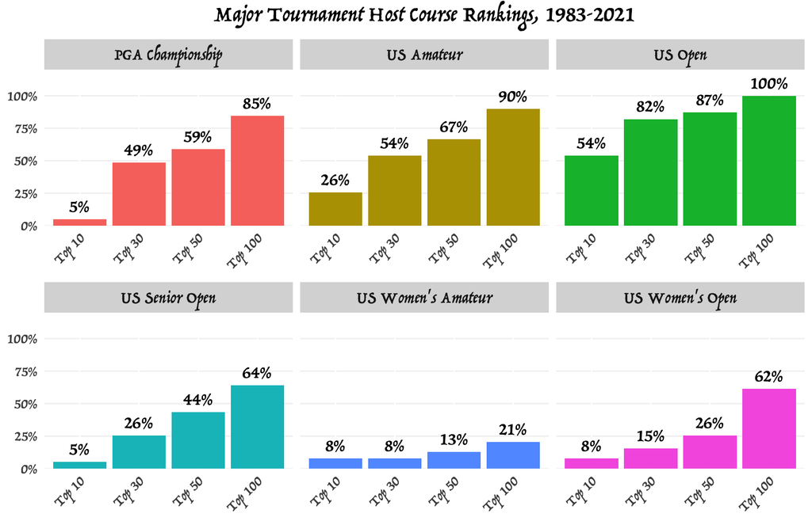

- **Befitting their stature as the country’s most prominent events - or perhaps indicating that raters disproportionately reward courses for hosting big tournaments - many of these tournaments are played at ranked venues.** Large majorities of all four men’s events, along with the US Women’s Open, held since 1983 have been contested at courses appearing in the Golf Magazine or Golf Digest Top 100 at the time of the tournament.
- **The US Open is in a class by itself, followed by the PGA Championship and US Amateur.** Every single US Open since 1983 has been played at a venue ranked in the top 100, and fully half have been played at a course in the top 10. By comparison, a quarter of US Amateurs have been played at top 10 courses and the number is in single digits for all of the other four events.
- **Men’s events have traditionally been held at more prestigious courses than women’s events.** While half or more of PGA Championships and US Amateurs were at courses in the top 30, only a quarter of US Women’s Opens have been held at courses in the top 50. Four out of five US Women’s Amateurs have been played at courses out of the rankings altogether. For all the talk of growing the women’s game, top courses have not stepped up to host the two most prominent USGA events for women. In fact, we will see some evidence later that the situation is getting worse.

### Changes over time

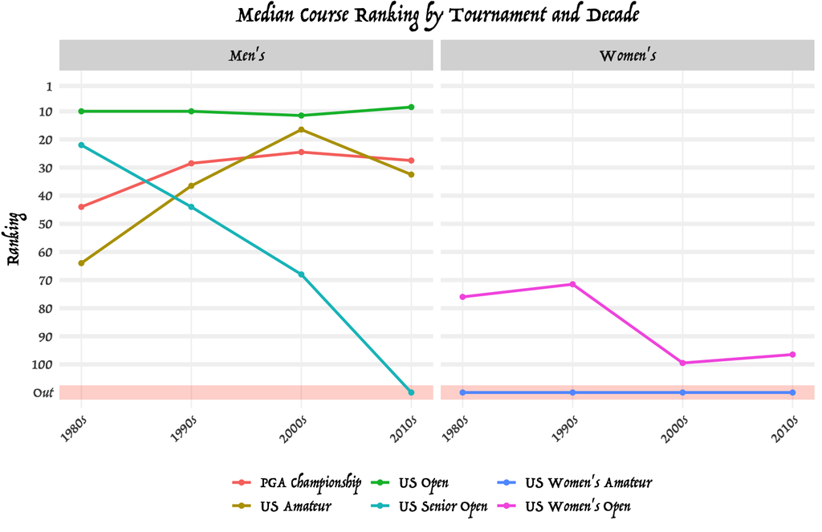

### Tournaments in detail

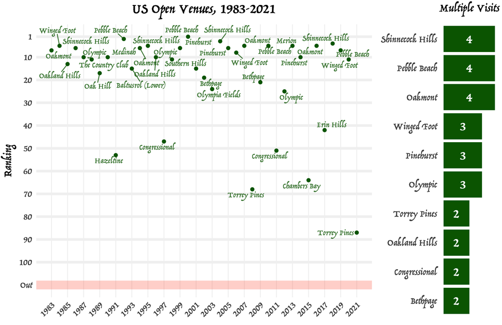

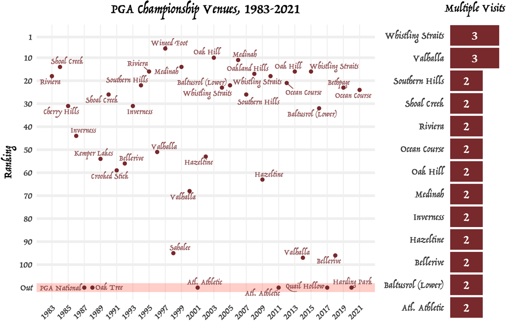

- **While top 10 courses are fixtures in the US Open, the typical PGA Championship course is one of the “best of the rest.”** Over the past thirty years, PGA venues have tended to come from the ranks of the nation’s top courses that aren’t in the US Open rotation. While the USGA has a lock on blue bloods like Shinnecock and Oakmont, the PGA rotation includes famous but lower-rated courses like Baltusrol, Oakland Hills and Oak Hill. This extends to public courses, as well - the PGA has made repeat visits to the Ocean Course and Whistling Straits, the top public options outside of Bandon, Oregon and USGA stalwarts Pebble Beach and Pinehurst.
- **Unlike the US Open, the PGA does visit unranked and barely-ranked courses.** The USGA is hyper-focused on prestige and protecting par. By contrast, the PGA is more flexible about winning scores and also maintains ownership interests that influence (or pollute) its hosting decisions. Bellerive, Atlanta Athletic, and Quail Hollow are large-scale, proven venues in metropolitan areas that may not excite golf architecture enthusiasts but maximize ticket sales and minimize player complaints. Meanwhile, Valhalla is owned by the PGA and Harding Park is administered by the PGA Tour’s TPC system.
- **The PGA does occasionally nab US Open venues - and may do so more often in the future.** Traditionally, when looking at former US Open courses that have moved to hosting PGA Championships, it would have been fair to describe them as courses in which the USGA has lost interest. Olympic changed that. Will more USGA venues follow suit and avoid having the my-way-or-the-highway blue blazer set screw up their courses?
- **Future venues continue the pattern of rotating between mid-ranked traditional hosts and PGA ownership interests, with a bias toward large metro areas:**
  - Best of the rest: Ocean Course, Oak Hill
  - USGA outcasts: Olympic, Baltusrol, Congressional, Southern Hills
  - Follow the money: Harding Park, Valhalla, PGA Frisco
  - Big crowds: With the exception of Valhalla and Southern Hills, all of them

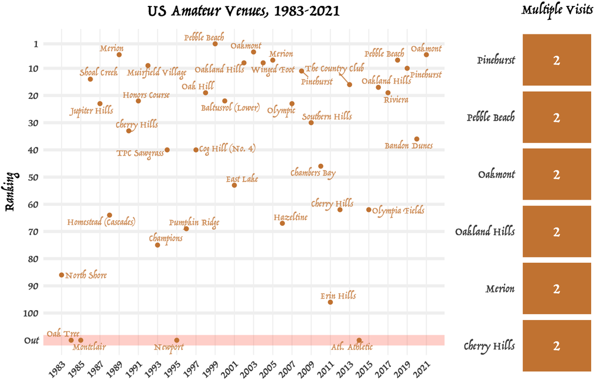

- **The US Amateur, still considered by some as a “major,” has host courses on par with the PGA Championship.** By some measures, the US Am is actually played on more prestigious courses than the PGA Championship, with multiple visits to places like Pinehurst, Merion, Oakmont and Pebble Beach since 1983 - places the PGA hasn’t visited for decades, if at all.
- **US Am venues, even more so than US Open venues, represent a Who’s Who of classic courses.** Even the four unranked courses are multiple-time major hosts.

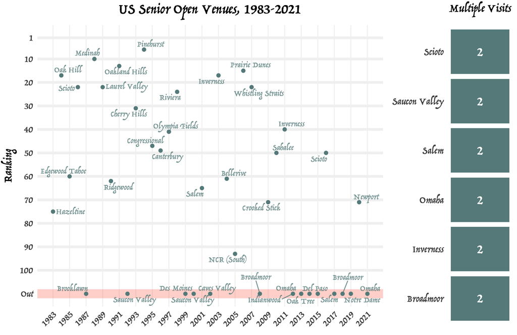

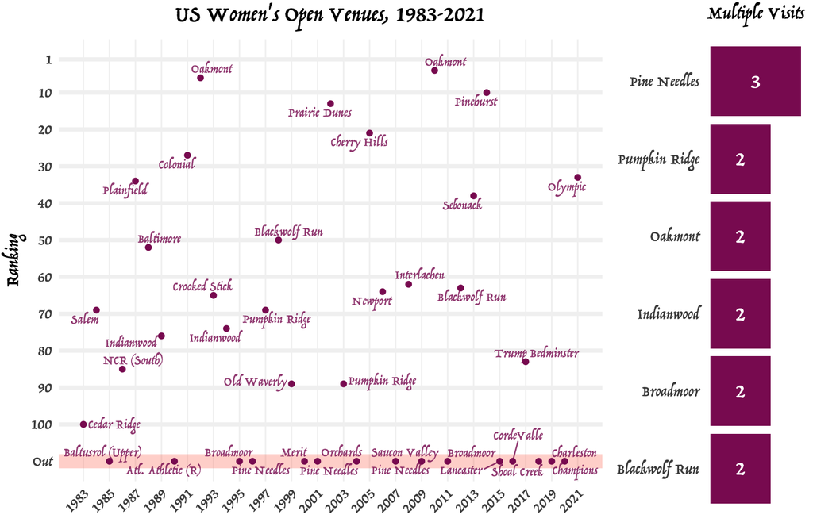

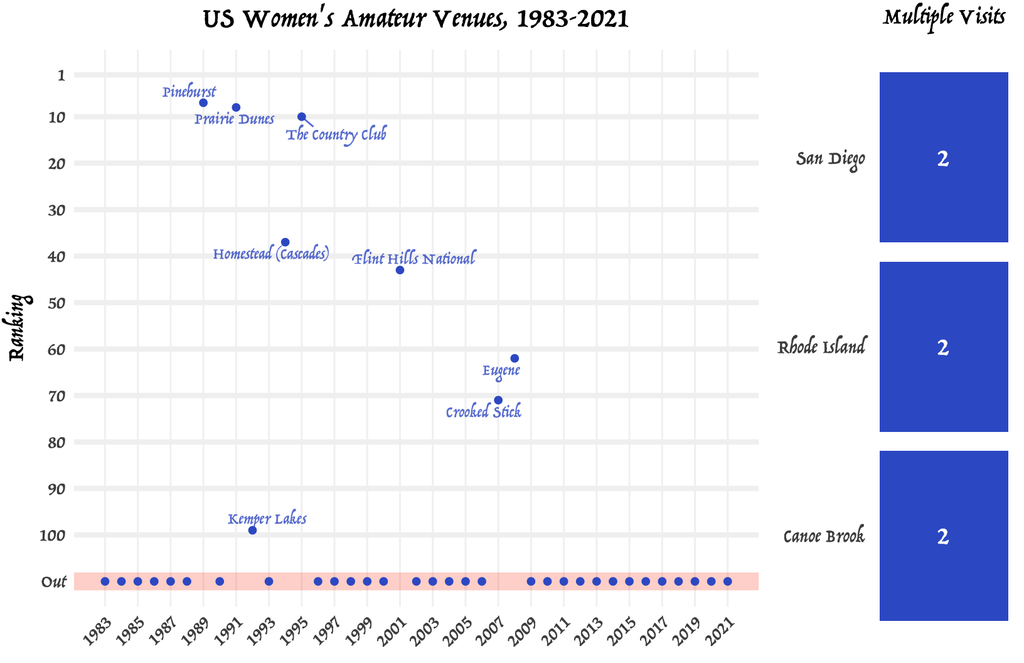

- **The situation is even more dire for the US Women’s Amateur.** The last time the best female amateurs played the US Women’s Am at a ranked course was 2008. They haven’t played at a top 30 course since 1995.

### A final question: who’s left?

In total, 118 courses have hosted major tournaments since 1983, 56 of which are currently ranked by one of the two magazines. That leaves 69 ranked courses which are off the tournament rotation. Seven of them are previous professional major hosts:

| Course | Current High Ranking | Number of Pro Majors | Most Recent |
| --- | --- | --- | --- |
| Chicago | 12 | 3 | 1911 |
| Garden City | 26 | 1 | 1902 |
| Winged Foot (East) | 41 | 3 | 1980 |
| Myopia Hunt | 63 | 4 | 1908 |
| Aronimink | 85 | 1 | 1962 |
| Philadelphia Cricket | 86 | 2 | 1910 |
| Moraine | 89 | 1 | 1945 |

Garden City is a men’s club and out for good. Myopia Hunt has made it more than 100 years without hosting an event and tops out under 6600 yards so it’s also probably out. In the interest of fairness and fan interest, Winged Foot would be better off allowing the women and senior men to play on its West course.

The others have actually already made comebacks of varying sorts - Chicago is now back in the limelight having hosted the inaugural US Senior Women’s Open, Aronimink is hosting the PGA Championship in a few years and has held FedEx Cup playoff events, and Philadelphia Cricket is hosting this year’s US Amateur Four-Ball. Moraine is not on the tournament rotation as of yet but in 2016 unveiled a highly lauded renovation that landed it back in the top 100 in Golf Magazine’s list.

| Course | Current High Ranking | Number of Pro Majors | Most Recent |
| --- | --- | --- | --- |
| Pine Valley | 1 | 0 | NA |
| Cypress Point | 2 | 0 | NA |
| National Golf Links | 5 | 0 | NA |
| Sand Hills | 9 | 0 | NA |
| Fishers Island | 10 | 0 | NA |
| Seminole | 12 | 0 | NA |
| Crystal Downs | 13 | 0 | NA |
| Los Angeles (North) | 13 | 0 | NA |
| Friar’s Head | 15 | 0 | NA |
| San Francisco | 16 | 0 | NA |
| Pacific Dunes | 17 | 0 | NA |

If LA Country Club can change its mind, then maybe a golf fan can dream?